# Prototype 2

## Prototype 2

### 1. Preliminary Data Preperation

##### 1.1 Data Import and Cleaning

The data cleaning and data reshape portions will not vary much from the Feature Prototype (FP), since the entire dataset is similarly formatted to the test dataset used in the FP.

One minor change is that we have chosen to remove the Computer Science Wikipedia Articles (CSAI) category from the HC3 dataset. This is as this category contains many wikipedia formatting tags that are difficult to remove, as they have no standardised format between tags. The CSAI category makes up an very small portion (~3%) of the entire dataset, and we believe that its removal is very unlikely to skew the dataset in a meaningful way, and it is safe to remove.

First, install the neccesary libraries and import modules

```python
# !pip install pandas
# !pip install numpy
# !pip install textblob
# !pip install nltk
```

```python
import pandas as pd
import json
```

Read the input jsonl file to an intermediate dataframe.

This time, we will read the entire HC3 dataset

```python
# convert jsonl to dataframe
with open('all.jsonl', encoding='utf8') as f:
    # read lines from jsonl into an intermediate df
    lines = f.read().splitlines()
    df_inter = pd.DataFrame(lines)
    df_inter.columns = ['json_element']
```

```python
df_inter.sample(3)
```

|  | json_element |
| --- | --- |
| 12552 | {"question":"What is that noise your computer ... |
| 5413 | {"question":"How are Nuclear Missiles Safely D... |
| 20898 | {"question":"Finding a good small business CPA... |

Next, split the dataframe into its respective columns

```python
#normalise the intermediate dataframe to seperate the data into columns
df = pd.json_normalize(df_inter['json_element'].apply(json.loads))
```

```python
df.sample(3)
```

|  | question | human_answers | chatgpt_answers | index | source |
| --- | --- | --- | --- | --- | --- |
| 6296 | Do dogs understand concepts like fish need wat... | [That dog is not trying to save the fish . He ... | [Dogs are intelligent animals, but it is unlik... | NaN | reddit_eli5 |
| 22213 | Is it advisable to go for an auto loan if I ca... | [What percentage of your savings is the full c... | [It is generally advisable to pay for a car in... | NaN | finance |
| 19976 | Can everyday people profit from unexpected wor... | [In the UK there are spread betting firms (ess... | [It is possible for everyday people to profit ... | NaN | finance |

Due to formatting issues (this category has a large amount of wikipedia formatting tags that vary greatly in format), we will also drop any rows that belong to the Computer Science Wikipedia Articles category (842 rows).

```python
prev_len = len(df) #find the current length of the dataframe before removal
prev_len
```

```
24322
```

```python
df = df[df.source != 'wiki_csai'] #remove the wiki_csai rows
df.reset_index(inplace=True, drop=True) #also reset the indexes of the dataframe
```

```python
cur_len = len(df)
prev_len - cur_len #check to make sure the correct number of rows was removed
```

```
842
```

```python
df.sample(3)
```

|  | question | human_answers | chatgpt_answers | index | source |
| --- | --- | --- | --- | --- | --- |
| 4981 | How do Mountains affect the weather ? I live a... | [Air that used to be at sea level changes its ... | [Mountains can have a big impact on the weathe... | NaN | reddit_eli5 |
| 410 | why is n't happy hour one single hour ? Why is... | [Because it is hard to drink enough in one hou... | [Happy hour is called happy hour because it is... | NaN | reddit_eli5 |
| 13963 | Why are the police : military of totalitarian ... | [There are two psychological terms , " ingroup... | [It's important to note that not all police of... | NaN | reddit_eli5 |

Now that we have removed the wiki_csai category, we can also drop the 'index' and 'source' columns, as they will not be used.

```python
df.drop(['index', 'source'], axis=1, inplace=True) # drop index and source columns
```

Next, we can inspect the data for missing values.

```python
# find any missing/NA values
df.isna().sum()
```

```
question           0
human_answers      0
chatgpt_answers    0
dtype: int64
```

No missing values were found.

Since each answer is a list, a list containing just empty strings, or an empty list will not be considered by panda's isna() function as a NA value. Thus, we will also inspect the dataframe for empty strings.

Some empty strings were found. Since these empty strings make up an insignificant portion of the dataset (~2%), they can be removed without significantly changing the makeup of the dataset.

```python
#check for empty strings
drop_cntr = 0
for i in range(len(df)):
    human_ans = df.at[i, 'human_answers']
    gpt_ans = df.at[i, 'chatgpt_answers']
    # if the answers are an empty string, or an empty list,
    if '' in human_ans or '' in gpt_ans or len(human_ans) == 0 or len(gpt_ans) == 0:
        #drop the row
        df.drop(i, axis=0, inplace=True)
        drop_cntr += 1
#print drop counter
print(f'dropped {drop_cntr} rows')
```

```
dropped 470 rows
```

Next, reset the indexes of the dataset without the removed rows (so that it can be iterated over later)

```python
df.reset_index(inplace=True)
df.drop(df.columns[0], axis=1, inplace=True)
```

We will describe the dataset to inspect the values contained within

```python
df.describe(include='all')
```

|  | question | human_answers | chatgpt_answers |
| --- | --- | --- | --- |
| count | 23010 | 23010 | 23010 |
| unique | 22482 | 21508 | 22447 |
| top | Why we learned to cover our private parts with... | [The attack on Pearl Harbor (called Hawaii Ope... | [!Only one message at a time. Please allow any... |
| freq | 2 | 3 | 14 |

We have also found some duplicate values, including duplicate questions, human answers, and chatgpt answers (which seems to be an error message)

These rows will be removed once the dataframe has been processed further (as it will be easier to remove them after the dataframe is converted to strings)

Next, we will inspect the dataframe's data types

```python
# check datatypes
df.dtypes
```

```
question           object
human_answers      object
chatgpt_answers    object
dtype: object
```

The dataframe will be converted to the string datatype.

```python
#convert to string
df = df.astype(str)
```

Next, we will need to strip the trailing/leading square brackets from the answers, and remove any newline characters (\n). We will also remove some Reddit text formatting tags and syntaxes.

```python
for i in range(len(df)):
    human_ans = df.at[i, 'human_answers']
    # strip leading/trailing square brackets and quotation marks
    human_ans = human_ans.lstrip('[\'\"')
    human_ans = human_ans.rstrip(']\'\"')
    human_ans = human_ans.replace('\\n', "") # remove all newline chars
    human_ans = human_ans.replace('\\r', "") # remove all carraige return chars
    human_ans = human_ans.replace('*', "") # remove reddit formatting *
    human_ans = human_ans.replace('[', "") # remove reddit formatting square brackets
    human_ans = human_ans.replace(']', "")
    df.at[i, 'human_answers'] = human_ans

    gpt_ans = df.at[i, 'chatgpt_answers']
    # strip leading/trailing square brackets and quotation marks
    gpt_ans = gpt_ans.lstrip('[\'\"')
    gpt_ans = gpt_ans.rstrip(']\'\"')
    gpt_ans = gpt_ans.replace('\\n', "") # remove all newline chars
    gpt_ans = gpt_ans.replace('\\r', "") # remove all carraige return chars
    gpt_ans = gpt_ans.replace('*', "") # remove reddit formatting *
    gpt_ans = gpt_ans.replace('[', "") # remove reddit formatting square brackets
    gpt_ans = gpt_ans.replace(']', "")
    df.at[i, 'chatgpt_answers'] = gpt_ans
```

```python
df.describe(include='all')
```

|  | question | human_answers | chatgpt_answers |
| --- | --- | --- | --- |
| count | 23010 | 23010 | 23010 |
| unique | 22482 | 21508 | 22445 |
| top | Why we learned to cover our private parts with... | The attack on Pearl Harbor (called Hawaii Oper... | !Only one message at a time. Please allow any ... |
| freq | 2 | 3 | 17 |

```python
df = df[df['chatgpt_answers'].str.contains('There was an error generating a response') == False]
```

We will also remove the duplicate questions and answers.

```python
df.drop_duplicates(subset = ['human_answers'], inplace=True)
df.drop_duplicates(subset = ['chatgpt_answers'], inplace=True)
df.drop_duplicates(subset = ['question'], inplace=True)
```

```python
df.describe(include ='all')
```

|  | question | human_answers | chatgpt_answers |
| --- | --- | --- | --- |
| count | 21398 | 21398 | 21398 |
| unique | 21398 | 21398 | 21398 |
| top | Why is every book I hear about a " NY Times # ... | Basically there are many categories of " Best ... | There are many different best seller lists tha... |
| freq | 1 | 1 | 1 |

Additionally, the HC3 dataset covers both Chinese and English answers. Though we only imported the English portion of the dataset, it would be advisable to ensure all answers are actually in English.

This check will be carried out using the langdetect python package, which is a Python port of Google's language detection library.

First, install and import langdetect

```python
#!pip install langdetect
```

```python
from langdetect import detect
```

Next, define a function to detect if the text is english.

```python
def detect_english(answer):
    # detects if the given answer is in English
    if (detect(answer) == 'en') == False:
        raise Exception() #detects if the
```

We will also reset the indexes of the dataframe so we can iterate through it

```python
df.reset_index(inplace=True)
```

Call the detect_english method on both the human and chatgpt answers to remove any non-English answers. Once again, this makes up an extremely small portion of the entire dataset

```python
drop_cntr = 0 # counter for number of rows dropped
for i in range(0, len(df)):
    # extract human and gpt answers
    human_ans = df.at[i, 'human_answers']
    gpt_ans = df.at[i, 'chatgpt_answers']

    try:
        # try to call detect_english on both answers
        detect_english(human_ans)
        detect_english(gpt_ans)
    except:
        # print error message if either answer raises an exception
        print(f'non-english answer at f{i}')
        # drop the row
        df.drop(i, axis=0, inplace=True)
        drop_cntr += 1

# print total rows dropped
print(f'dropped {drop_cntr} rows')
```

```
non-english answer at f15299
non-english answer at f15520
non-english answer at f15878
non-english answer at f15908
non-english answer at f17052
non-english answer at f20613
non-english answer at f20659
non-english answer at f20681
dropped 8 rows
```

This results in a cleaned dataset that is about 88% the size of the original dataset. In our opinion, the majority of the original dataset is preserved, and the cleaning is unlikely to significantly affect our results.

##### 1.2 Data Reshape

We will also need to reshape the dataframe to seperate human and chatgpt answers into distinct rows.

First, we will seperate the dataframe into 2 seperate dataframes, each containing only 1 type of answer.

We will also add an additional 'is_human' column to each dataframe, indicating if the answer was generated by a human

```python
# retrieve human answers
df_human = df[['question', 'human_answers']].copy() #copy the question and human answers
df_human['is_human'] = 1 #set a column indicating if the answer is human
df_human.rename(columns = {'human_answers':'answer'}, inplace = True) # rename column to answer
df_human.sample(2)
```

|  | question | answer | is_human |
| --- | --- | --- | --- |
| 7619 | Why do people close their eyes when they hear ... | Loud noises usually mean explosions or alike ,... | 1 |
| 2941 | What is DNS and DHCP . I have no idea . Please... | DNS is like a phone book . You either know... | 1 |

```python
# do the same for chatgpt answers
df_gpt = df[['question', 'chatgpt_answers']].copy()
df_gpt['is_human'] = 0
df_gpt.rename(columns = {'chatgpt_answers':'answer'}, inplace = True)
df_gpt.sample(2)
```

|  | question | answer | is_human |
| --- | --- | --- | --- |
| 5069 | Why ca n't you use laptop parts for a PC ? I k... | \While it is possible to use some laptop parts... | 0 |
| 10736 | What is this new " Common Core " math ? I feel... | Common Core" is a set of standards for math an... | 0 |

Next, both dataframes will be concatenated to join them together into a cleaned dataframe

```python
# concat both dataframes
df_cleaned = pd.concat([df_human, df_gpt])
df_cleaned.sample(3)
```

|  | question | answer | is_human |
| --- | --- | --- | --- |
| 3146 | What can high - profile law firms do to win ca... | High-profile law firms often have more resourc... | 0 |
| 6474 | Do Cubans get to pick their job ? Communism me... | In a communist system, the government typicall... | 0 |
| 9653 | Evolution Please explain to me Evolution , the... | Basically it is very Very simple . So simple t... | 1 |

We will also use the panda's value_counts function to ensure that there is the expected number of each type of answer

```python
# sum is_human to ensure there is a 50:50 split of answers
df_cleaned['is_human'].value_counts()
```

```
is_human
1    21390
0    21390
Name: count, dtype: int64
```

Lastly, we will shuffle the order of the answers

```python
# shuffle human and chatgpt generated answers
df_cleaned = df_cleaned.sample(frac = 1).reset_index(drop=True)
```

```python
df_cleaned.sample(3)
```

|  | question | answer | is_human |
| --- | --- | --- | --- |
| 32147 | what happened on the moon during the period of... | During this event a very large number of the i... | 1 |
| 17350 | The causes of WWI . Other than MANIA , I 'm so... | Franco - Russian alliance : France angry over ... | 1 |
| 31871 | why does ice freeze hard but ice cream freeze ... | Ice cream is made with cream, which is a liqui... | 0 |

##### 1.3 Lemmatisation

We will also create both a lemmatised, and a filtered (both lemmatised, and stopword-removed) version of each answer for later usage in some methods, such as sentiment analysis.

Compared to stemming, lemmatisation preserves the context and meaning of a word whe converting it to its base form. Preserving the context and meaning of each word will allow for a more accurate sentiment analysis

First, download NLTK packages, and import the required modules.

```python
# Also download NLTK packages
nltk.download('stopwords')
nltk.download('punkt')

import nltk
from nltk.corpus import stopwords
from nltk.stem import WordNetLemmatizer
from nltk.tokenize import word_tokenize
```

Next, initialise the lemmatiser, and the corpus of stopwords. The stopword corpus used will be NLTK's general English stopword corpus.

```python
# init lemmatiser and stopwords
lemmatizer = WordNetLemmatizer()
stopwords = stopwords.words('english')

# also create empty columns for filtered/lemmatised answers
df_cleaned['filtered_answer'] = ""
df_cleaned['lemmatised_answer'] = ""
```

Next, iterate through each answer, processing each answer by either:

1. just lemmatising the answer, or
2. both removing stopwords and lemmatising the answer.

```python
for i in range(len(df_cleaned)):

    answer = df_cleaned.at[i, 'answer'] #retrieve answer text from df
    tokens = word_tokenize(answer) # tokenise the answer

    # lemmatise answer
    lemmatised_tokens = [lemmatizer.lemmatize(token) for token in tokens]
    # reconstruct the answer as a string, and store lemmatised answer in column
    df_cleaned.at[i, 'lemmatised_answer'] = ' '.join(lemmatised_tokens)

    # remove stopwords
    tokens_no_stopwords = [token for token in tokens if token not in stopwords]
    # lemmatise stopword-removed answer
    lemmatised_tokens_no_stopwords = [lemmatizer.lemmatize(token) for token in tokens_no_stopwords]

    # reconstruct the answer as a string, and store filtered answer in column
    df_cleaned.at[i, 'filtered_answer'] = ' '.join(lemmatised_tokens_no_stopwords)
```

```python
df_cleaned.sample(3)
```

|  | question | answer | is_human | filtered_answer | lemmatised_answer |
| --- | --- | --- | --- | --- | --- |
| 21766 | What does it mean for issuing corporations to ... | When markets are "frothy," it means that inves... | 0 | When market `` frothy , '' mean investor willi... | When market are `` frothy , '' it mean that in... |
| 24652 | How do Key Generators work and why are n't gam... | This is actually two separate things , key gen... | 1 | This actually two separate thing , key gen n\'... | This is actually two separate thing , key gen ... |
| 1890 | Who makes malware , viruses , and trojans ? Wh... | Pretty much anyone with a knowledge of compute... | 1 | Pretty much anyone knowledge computer programm... | Pretty much anyone with a knowledge of compute... |

### 2. Feature Extraction

##### 2.1 Basic Textual Features

We will extract a similar set of features to the ones used by Fröhling and Zubiaga [2021] - word count, sentence count, character count, average word length, and average sentence length.

```python
# import sentence and word tokenisers
from nltk.tokenize import sent_tokenize
from nltk.tokenize import word_tokenize
```

```python
#initialise columns for the extracted features
df_cleaned['word_count'] = 0
df_cleaned['sentence_count'] = 0
df_cleaned['char_count'] = 0
df_cleaned['avg_sentence_len'] = 0
df_cleaned['avg_word_len'] = 0
```

Next, iterate through each answer, extracting the selected features.

```python
for i in range(len(df_cleaned)):
    answer = df_cleaned.at[i, 'answer'] # extract answer text from df

    ans_sent_token = sent_tokenize(answer)# tokenise answer into sentences
    sentence_count = len(ans_sent_token)# calculate sentence count
    df_cleaned.at[i, 'sentence_count'] = sentence_count

    ans_word_token = word_tokenize(answer) # tokenise answer into words
    word_count = len(ans_word_token)  # calculate word count
    df_cleaned.at[i, 'word_count'] = word_count

    char_count = len(answer) # calculate character count
    df_cleaned.at[i, 'char_count'] =  char_count

    df_cleaned.at[i, 'avg_sentence_len'] = word_count/sentence_count # calculate average sentence length
    df_cleaned.at[i, 'avg_word_len'] =  char_count/word_count   # calculate average word length
```

```python
df_cleaned.sample(2)
```

|  | question | answer | is_human | filtered_answer | lemmatised_answer | word_count | sentence_count | char_count | avg_sentence_len | avg_word_len |
| --- | --- | --- | --- | --- | --- | --- | --- | --- | --- | --- |
| 8632 | Why is the phrase " Fuck you " so gravely offe... | The phrase "fuck you" is considered a very rud... | 0 | The phrase `` fuck '' considered rude offensiv... | The phrase `` fuck you '' is considered a very... | 154 | 4 | 762 | 38.5 | 4.948052 |
| 31332 | Do I owe taxes if my deductions are higher tha... | In your case, I believe the answer is that you... | 1 | In case , I believe answer don\'t owe tax , de... | In your case , I believe the answer is that yo... | 82 | 4 | 369 | 20.5 | 4.500000 |

##### 2.2 Sentiment Analysis

4 metrics will be assessed – negativity, neutrality, subjectivity, and overall polarity.

To calculate overall polarity, we will use 2 analysers - NLTK's VADER and TextBlob. This will allow us to obtain a secondary opinion, and provide a more accurate compound score.

The rest of the metrics will be extracted using only 1 analyser, as each analyser supports a different set of metrics. Negativity and neutrality will be extracted using VADER, and subjectivity will be extracted by Textblob.

First, import the required modules and download the required VADER NLTK package.

```python
from nltk.sentiment import SentimentIntensityAnalyzer
from textblob import TextBlob
```

```python
nltk.download('vader_lexicon')
```

```
True
```

We will also initialise empty columns for the extracted features.

```python
# initialise columns for the extracted features
df_cleaned['polarity'] = 0
df_cleaned['negativity'] = 0
df_cleaned['neutrality'] = 0
df_cleaned['subjectivity'] = 0
```

Next, initialise the NLTK VADER sentiment analyser (TextBlob does not need to be initialise using a constructor)

```python
analyser = SentimentIntensityAnalyzer()
```

Next, iterate through each filtered answer (lemmatised + stopwords removed), extracting the negativity (NLTK only), neutrality (NLTK only), polarity (both), and subjectivity (TextBlob only) of each answer.

```python
for i in range(len(df_cleaned)):
    answer = df_cleaned.at[i, 'filtered_answer']
    #analyse filetered answers
    nltk_scores = analyser.polarity_scores(answer)
    textblob_scores = TextBlob(answer).sentiment

    # extract neg and neu using nltk
    df_cleaned.at[i, 'negativity'] = nltk_scores['neg']
    df_cleaned.at[i, 'neutrality'] = nltk_scores['neu']

    # calculate average polarity by using results from both analysers
    df_cleaned.at[i, 'polarity'] = (nltk_scores['compound'] + textblob_scores.polarity)/2

    # extract subjectivity using textblob
    df_cleaned.at[i, 'subjectivity'] = textblob_scores.subjectivity
```

```python
df_cleaned.sample(3)
```

|  | question | answer | is_human | filtered_answer | lemmatised_answer | word_count | sentence_count | char_count | avg_sentence_len | avg_word_len | polarity | negativity | neutrality | subjectivity |
| --- | --- | --- | --- | --- | --- | --- | --- | --- | --- | --- | --- | --- | --- | --- |
| 37525 | Whats the difference between a qualified and a... | Yes, as long as you write a call against your ... | 1 | Yes , long write call stock strike price great... | Yes , a long a you write a call against your s... | 387 | 10 | 1976 | 38.700000 | 5.105943 | 0.546519 | 0.076 | 0.787 | 0.343298 |
| 3863 | Why does my body produce so much mucus when I ... | Your body produces mucus from mucous membranes... | 1 | Your body produce mucus mucous membrane presen... | Your body produce mucus from mucous membrane w... | 210 | 13 | 1061 | 16.153846 | 5.052381 | -0.490357 | 0.184 | 0.737 | 0.471939 |
| 8800 | Why do hospitals have religious sounding names... | Hospitals often have religious sounding names ... | 0 | Hospitals often religious sounding name founde... | Hospitals often have religious sounding name b... | 188 | 10 | 1062 | 18.800000 | 5.648936 | 0.496864 | 0.000 | 0.820 | 0.288768 |

##### 2.3 Syntactic and Lexical Density

##### 2.3.1 Lexical Density

First, we will extract the lexical density of each answer. This will involve counting the number of lexical terms in each answer (nouns/proper nouns, adjectives, verbs, prepositions, and adverbs), and dividing them by the total number of words in the answer.

First, install and import spaCy, and download the pre-trained en_core_web_sm model, which is optimised for CPU processing.

```python
#!pip install spacy
#!python -m spacy download en_core_web_sm
```

```python
import spacy
```

Also, create an empty column for the lexical density feature

```python
df_cleaned['lexical_density'] = 0 # create an empty column for lexical density
```

Load the spacy en_core_web_sm model, and a list of POS tags that denote lexical words

```python
nlp = spacy.load("en_core_web_sm") # load spacy model
tags = ['PROPN', 'ADJ', 'NOUN', 'VERB', 'ADP', 'ADV'] # load list of desired lexical word tags
```

Finally, iterate through every row and count the number of lexical words. Then, divide the number of lexical words by the total word count to calculate the lexical density of each answer.

```python
for i in range(len(df_cleaned)):

    answer = df_cleaned.at[i, 'answer'] #extract the answer text
    word_count = df_cleaned.at[i, 'word_count'] #extract word count

    lexical_word_cntr  = 0 #initialise counter for lexical words
    ans_pos = nlp(answer) # analyse answer text using model

    # for each word in the analysed answer
    for token in ans_pos:
        # check if it is a lexical word (POS tag is in the list of desired tags)
        if token.pos_ in tags:
            lexical_word_cntr += 1

    df_cleaned.at[i, 'lexical_density'] = lexical_word_cntr/word_count # calculate lexical density
```

##### 2.3.2 Named Entity Count

Next, we will extract the named entity features. The count of named entities will be extracted using spaCy.

```python
df_cleaned['NE_count'] = 0
```

```python
for i in range(len(df_cleaned)):
    answer = df_cleaned.at[i, 'answer'] #extract the answer text
    ans_NE = nlp(answer) # analyse answer text using the spaCy model
    df_cleaned['NE_count'] = len(ans_NE.ents) #retrieved the NE count for each answer
```

```python
df_cleaned.sample(1)
```

|  | question | answer | is_human | filtered_answer | lemmatised_answer | word_count | sentence_count | char_count | avg_sentence_len | avg_word_len | polarity | negativity | neutrality | subjectivity | lexical_density | NE_count |
| --- | --- | --- | --- | --- | --- | --- | --- | --- | --- | --- | --- | --- | --- | --- | --- | --- |
| 12654 | What causes light headedness, nausea and fever... | There could be a number of potential causes fo... | 0 | There could number potential cause lightheaded... | There could be a number of potential cause for... | 163 | 4 | 851 | 40.75 | 5.220859 | 0.5842 | 0.093 | 0.666 | 0.775 | 0.521472 | 4 |

Since this feature takes a significant time to extract, we will save the current data to a csv file.

This avoids the need to re-run the entire code again when refreshing the jupyter kernel/restarting the notebook.

```python
df_cleaned.to_csv('intermediate_data_1.csv', mode='w')
```

##### 2.3.3 Coreference Cluster Features

Next, we will also extract the Coreference Cluster features - average coreference cluster length, and number of coreference clusters.

This will be extracted using a pre-trained en_coreference_web_trf model from SpaCy's experimental package.

First, we will need to install spacy-experimental, and download the pre-trained coreference cluster model.

We will also install the tqdm package to print out a progress bar, so we can visualise the progress of the coreference cluster feature extraction (as coreference cluster extraction takes roughly 11-12 hours for the entire dataset)

First, install the required packages and import modules

```python
#!pip install spacy-experimental
#!pip install https://github.com/explosion/spacy-experimental/releases/download/v0.6.1/en_coreference_web_trf-3.4.0a2-py3-none-any.whl
#!pip install tqdm
```

```python
import spacy
import spacy_transformers
from tqdm import tqdm
```

Load the pretrained model, and read in the data from the intermediate csv file we saved earlier

```python
coref = spacy.load("en_coreference_web_trf")
```

[output not shown]

```python
df_cleaned = pd.read_csv('intermediate_data_1.csv')
```

Also, create empty columns for the coreference cluster features

```python
 # create empty columns for the coreference features
df_cleaned['coref_count'] = 0
df_cleaned['avg_coref_len'] = 0
```

Next, iterate over all rows in the dataframe, and extract the coreference spans (clusters).

This will allow us to count the number of coreference clusters, and calculate the average length of each cluster,

```python
for i in tqdm(range(0, len(df_cleaned))):
        answer = df_cleaned.at[i, 'answer'] #retrieve answer from df
        doc = coref(answer) # analyse answer using pretrained coref model

        coref_count = len(doc.spans) #get number of coref spans (clusters)

        # skip answer if no coref spans detected, since no clusters results in a 0 coref cluster count and 0 avg coref length
        # avoids div by 0 error
        if coref_count == 0:
            continue

        # initialise counter for total length of all coref spans
        total_span_len = 0
        # iterate over all spans, and add their length to the counter
        for span in doc.spans:
            total_span_len += len(doc.spans[span])

        avg_span_len = total_span_len/coref_count #calcuate average span length

        # set values in df
        df_cleaned.at[i, 'avg_coref_len'] = avg_span_len
        df_cleaned.at[i, 'coref_count'] = coref_count
```

Once again, we will save this to an intermediate csv file to avoid having to rerun this extraction again.

```python
df_cleaned.to_csv('intermediate_data_2.csv', mode='w')
```

##### 2.4 Frequency

We will also be extracting 3 frequency features:

1. Zipfian distribution difference
2. Unique word count
3. Stop word count

##### 2.4.1 Zipfian Difference

We will extract the difference between the text's Zipfian distribution line, and the Zipf's law line. (which we will refer to as Zipfian Difference)

First, install matplotlib, which will be used to assist in visualising this method.

Also, import the neccessary modules

```python
# !pip install matplotlib
```

```python
import string
import collections
import pandas as pd
import nltk
from nltk import word_tokenize
import matplotlib.pyplot as plt
import numpy as np
from tqdm import tqdm
```

We will also read in the csv file saved in the last step

```python
df_cleaned = pd.read_csv('intermediate_data_2.csv')
```

```python
df_cleaned.sample(3)
```

[output not shown]

In order to better illustrate this method, we will show the entire process on a random sample answer, before applying it to the entire text.

To start, we will extract the lemmatised answer (inclusive of stopwords) from the dataframe, and strip its punctuation. The lemmatised answer is used to reduce each word to its base form for counting (e.g., jump, jumped, jumping should all be reduced to 'jump' for counting)

```python
answer = df_cleaned.at[np.random.randint(0, high = len(df_cleaned)), 'lemmatised_answer'] #extract lemmatised answer
answer = answer.translate(str.maketrans('', '', string.punctuation)) # strip punctuation
```

Next, we will tokenise the answer, and convert it to a frequency distribution

```python
tokens = word_tokenize(answer) #tokenise answer
freq_dist = nltk.FreqDist(tokens) # create freqdist
freq_dist
```

```
FreqDist({'a': 8, 'to': 5, 'of': 5, 'the': 5, 'can': 4, 'economic': 4, 'recession': 4, 'change': 4, 'in': 4, 'and': 4, ...})
```

Next, we will convert the frequency distribution to a ordered dictionary, sorted in descending order of word frequency.

This is so we can preseve the order of the dictionary, which will be used to plotting later on.

```python
freq_dict = dict([(m, n) for m, n in freq_dist.items()]) # create dictionary from frequecy distribution
freq_dict = collections.OrderedDict(dict(sorted(freq_dict.items(), key=lambda item: item[1], reverse=True))) # sort the items, and create an ordered dictionary
print(freq_dict)
```

```
OrderedDict([('a', 8), ('to', 5), ('of', 5), ('the', 5), ('can', 4), ('economic', 4), ('recession', 4), ('change', 4), ('in', 4), ('and', 4), ('I', 3), ('is', 3), ('business', 3), ('may', 3), ('provide', 2), ('what', 2), ('However', 2), ('time', 2), ('economy', 2), ('or', 2), ('overall', 2), ('level…
```

Next, we will need to change the key from a word to its frequency rank (e.g., 1st, 2nd, 3rd most frequent word) using a counter.

As ordered dictionaries are immutable, we will instead use a new dictionary, final_freq_dict, and add each item in freq_dict to this dictionary.

```python
cntr = 1 #initialise counter
final_freq_dict = collections.OrderedDict() #initliase final frequency dict

for key in freq_dict.keys():
    final_freq_dict[cntr] = freq_dict[key] # add each item to final_freq_dict, and change the key to the frequency rank
    cntr += 1 #increment counter

print(final_freq_dict)
```

```
OrderedDict([(1, 8), (2, 5), (3, 5), (4, 5), (5, 4), (6, 4), (7, 4), (8, 4), (9, 4), (10, 4), (11, 3), (12, 3), (13, 3), (14, 3), (15, 2), (16, 2), (17, 2), (18, 2), (19, 2), (20, 2), (21, 2), (22, 2), (23, 2), (24, 2), (25, 2), (26, 1), (27, 1), (28, 1), (29, 1), (30, 1), (31, 1), (32, 1), (33, 1),…
```

Next, we will plot the scatter plot, and its best fit line on a log-log scale.

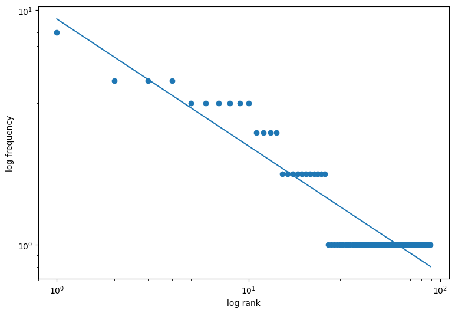

```python
x = np.array([int(i) for i in final_freq_dict.keys()]) # frequency rank as x axis
y = np.array([int(i) for i in final_freq_dict.values()]) # frequency percentage as y axis

fig, ax = plt.subplots(figsize = (9, 6))

# change scale to log-log
ax.set_yscale("log")
ax.set_xscale("log")

#set x and y labels
plt.xlabel('log rank')
plt.ylabel('log frequency')

#add plot scatter plot
ax.scatter(x, y)

# calcuate best fit line on a log-log scale (referenced from Craig [2017])
slope, intercept = np.polyfit(np.log(x), np.log(y), 1) # fit log(y) = m*log(x) + c
y_fit = np.exp(slope * np.log(x) + intercept) # calculate the fitted values of y
ax.plot(x, y_fit)

plt.show()
```

In order to calcuate the difference between the text' Zipfian Difference, we will use the absolute difference in the gradient between the plotted line, and the Zipf's law line (which has a gradient of -1 on a log-log scale)

```python
print(f'The line gradient is: {slope}')
print(f'The difference between the line and Zipf\'s law is {np.absolute(-1 - slope)}')
```

```
The line gradient is: -0.5413753485139352
The difference between the line and Zipf's law is 0.4586246514860648
```

Next, we will gather the above method into a function (minus the line plotting code, as we only need the gradient of the line, and do not need to plot and show the actual graph) called calc_zipfian_diff, so we can call it on each row of the dataframe.

```python
def calc_zipfian_diff(row):
    answer = df_cleaned.at[row, 'lemmatised_answer'] #extract answer
    answer = answer.translate(str.maketrans('', '', string.punctuation)) # strip punctuation
    tokens = word_tokenize(answer) #tokenise answer
    freq_dist = nltk.FreqDist(tokens) # create freqdist

    freq_dict = dict([(m, n) for m, n in freq_dist.items()]) # create dictionary from frequecy distribution
    freq_dict = collections.OrderedDict(dict(sorted(freq_dict.items(),
                                            key=lambda item: item[1], reverse=True))) # sort the items, and create an ordered dictionary

    cntr = 1 #initialise counter
    final_freq_dict = collections.OrderedDict() #initliase final frequency dict

    for key in freq_dict.keys():
        final_freq_dict[cntr] = freq_dict[key] # add each item to final_freq_dict, and change the key to the frequency rank
        cntr += 1 #increment counter

    x = np.array([int(i) for i in final_freq_dict.keys()]) # frequency rank as x axis
    y = np.array([int(i) for i in final_freq_dict.values()]) # frequency percentage as y axis

    # calcuate best fit line on a log-log scale
    slope, intercept = np.polyfit(np.log(x), np.log(y), 1) # fit log(y) = m*log(x) + c


    zipfian_diff = np.absolute(-1 - slope) # get absolute difference between the gradient and Zipf's Law line

    return zipfian_diff
```

Next, we can call the function on each row to find the Zipfian Difference for each answer.

```python
df_cleaned['zipfian_difference'] = 0 #initalise empty column for zipfian difference
```

```python
for i in range(0, len(df_cleaned)):
    df_cleaned.at[i, 'zipfian_difference'] = calc_zipfian_diff(i)
```

```python
df_cleaned.sample(3)
```

|  | Unnamed: 0.1 | Unnamed: 0 | question | answer | is_human | filtered_answer | lemmatised_answer | word_count | sentence_count | char_count | ... | avg_word_len | polarity | negativity | neutrality | subjectivity | lexical_density | NE_count | coref_count | avg_coref_len | zipfian_difference |
| --- | --- | --- | --- | --- | --- | --- | --- | --- | --- | --- | --- | --- | --- | --- | --- | --- | --- | --- | --- | --- | --- |
| 35252 | 35252 | 35252 | Why is it recommended to pee on someone who ha... | It is n't . Much better to use vinegar , and s... | 1 | It n't . Much better use vinegar , simply some... | It is n't . Much better to use vinegar , and s... | 125 | 8 | 588 | ... | 4.704000 | -0.004642 | 0.133 | 0.744 | 0.411310 | 0.432000 | 4 | 4 | 3.25 | 0.674042 |
| 23770 | 23770 | 23770 | how long have kanab ambersnail been endangered? | It has been listed as endangered on the United... | 1 | It listed endangered United States Fish Wildli... | It ha been listed a endangered on the United S... | 23 | 1 | 127 | ... | 5.521739 | 0.210750 | 0.000 | 0.823 | 0.000000 | 0.565217 | 4 | 0 | 0.00 | 0.887962 |
| 40469 | 40469 | 40469 | Why is n't widescreen a television standard , ... | It was easier to make TVs in the old aspect ra... | 1 | It easier make TVs old aspect ratio back tv gi... | It wa easier to make TVs in the old aspect rat... | 214 | 10 | 1031 | ... | 4.817757 | -0.054386 | 0.027 | 0.948 | 0.437516 | 0.551402 | 4 | 2 | 2.00 | 0.446400 |

3 rows × 21 columns

##### 2.4.2 Unique Word Count and Stopword Count

We will also extract the unique word proportion and stopword proportion for each text.

We will quantify this by:

1. extracting the proportion of unique words in each answer, divided over the length of the entire answer
2. extracting the proportion of the answer that is made up of stopwords

```python
from nltk import word_tokenize
from nltk.corpus import stopwords
```

```python
# initialise stopwords
stopwords = stopwords.words('english')
```

```python
df_cleaned['unique_word_proportion'] = 0
df_cleaned['stopword_proportion'] = 0
```

```python
for i in range(0, len(df_cleaned)):
    answer = df_cleaned.at[i, 'answer'] #retrieve answer from df
    word_count = df_cleaned.at[i, 'word_count'] #extract word count from df

    tokens = word_tokenize(answer) # tokenise answer

    unique_word_count = len(set(tokens)) # get number of unique words

    tokens_no_stopwords = [token for token in tokens if token not in stopwords] # create a list of tokens without stopwords
    stopword_count = word_count - len(tokens_no_stopwords) # calculate number of stopwords

    df_cleaned.at[i, 'unique_word_proportion'] = (unique_word_count/word_count) #calcuate unique word proportion
    df_cleaned.at[i, 'stopword_proportion'] = (stopword_count/word_count) # calculate stopword proportion
```

```python
df_cleaned.sample(3)
```

|  | Unnamed: 0.1 | Unnamed: 0 | question | answer | is_human | filtered_answer | lemmatised_answer | word_count | sentence_count | char_count | ... | negativity | neutrality | subjectivity | lexical_density | NE_count | coref_count | avg_coref_len | zipfian_difference | unique_word_proportion | stopword_proportion |
| --- | --- | --- | --- | --- | --- | --- | --- | --- | --- | --- | --- | --- | --- | --- | --- | --- | --- | --- | --- | --- | --- |
| 6034 | 6034 | 6034 | Why is voltage used as opposed to current to w... | Voltage is used as a measure of electric hazar... | 0 | Voltage used measure electric hazard closely r... | Voltage is used a a measure of electric hazard... | 187 | 6 | 975 | ... | 0.242 | 0.621 | 0.533889 | 0.556150 | 4 | 6 | 2.000000 | 0.329947 | 0.491979 | 0.481283 |
| 40851 | 40851 | 40851 | What happens when someone gives birth on a pla... | > What citizenship does child hold ? It obviou... | 1 | > What citizenship child hold ? It obviously v... | > What citizenship doe child hold ? It obvious... | 159 | 7 | 787 | ... | 0.000 | 0.880 | 0.591667 | 0.534591 | 4 | 2 | 3.000000 | 0.492438 | 0.622642 | 0.408805 |
| 42016 | 42016 | 42016 | the Classes of ships and subs So I 've seen th... | There are many different classes of ships and ... | 0 | There many different class ship submarine worl... | There are many different class of ship and sub... | 199 | 4 | 1039 | ... | 0.135 | 0.789 | 0.600000 | 0.552764 | 4 | 7 | 2.857143 | 0.331730 | 0.502513 | 0.487437 |

3 rows × 23 columns

We will save this to an intermediate csv file

```python
df_cleaned.to_csv('intermediate_data_3.csv', mode='w')
```

##### 2.5 Complex Phrase Features

We will also be extracting the count of 2 different types of complex phrases - Ancient phrases and Cliches.

This will be done by comparing the answer to reference lists of each type of phrase, which have been compiled and cleaned from 2 online sources.

First, we will import the required modules and read in the intermediate csv from the last step

```python
import pandas as pd
import csv
```

```python
df_cleaned = pd.read_csv('intermediate_data_3.csv')
df_cleaned.sample(3)
```

|  | Unnamed: 0.2 | Unnamed: 0.1 | Unnamed: 0 | question | answer | is_human | filtered_answer | lemmatised_answer | word_count | sentence_count | ... | negativity | neutrality | subjectivity | lexical_density | NE_count | coref_count | avg_coref_len | zipfian_difference | unique_word_proportion | stopword_proportion |
| --- | --- | --- | --- | --- | --- | --- | --- | --- | --- | --- | --- | --- | --- | --- | --- | --- | --- | --- | --- | --- | --- |
| 312 | 312 | 312 | 312 | We have time zones on Earth , so what time is ... | Space does n't have time zones so everyone agr... | 1 | Space n't time zone everyone agreed say want s... | Space doe n't have time zone so everyone agree... | 116 | 6 | ... | 0.0 | 0.877 | 0.251339 | 0.577586 | 4 | 2 | 3.000000 | 0.559690 | 0.663793 | 0.301724 |
| 22220 | 22220 | 22220 | 22220 | How do small towns in the US sustain themselve... | Small towns in the US often rely on a mix of l... | 0 | Small town US often rely mix local business , ... | Small town in the US often rely on a mix of lo... | 202 | 6 | ... | 0.0 | 0.770 | 0.380000 | 0.658416 | 4 | 7 | 2.142857 | 0.321069 | 0.435644 | 0.346535 |
| 41757 | 41757 | 41757 | 41757 | what is the purpose of education in USA ? Job ... | The purpose of education in the United States ... | 0 | The purpose education United States help peopl... | The purpose of education in the United States ... | 204 | 8 | ... | 0.0 | 0.783 | 0.498556 | 0.627451 | 4 | 5 | 2.600000 | 0.349759 | 0.485294 | 0.392157 |

3 rows × 24 columns

Next, read in the 2 reference lists from their respective csv files into python lists.

First, we will define a function to convert a csv file to a list

```python
def csv_to_list(filepath):
    # open csv file
    with open(filepath, 'r') as file:
        reader = csv.reader(file) # read csv file
        data = []
        for row in reader:
            data.append(row[0]) # append each row to data list
    return data
```

and call it on the two reference csv files.

```python
cliches = csv_to_list('phrases/cliches.csv')
ancient_phrases = csv_to_list('phrases/ancient_phrases.csv')

print(cliches)
print(ancient_phrases)
```

```
['ace in the hole', 'ace up your sleeve', 'acid test', 'airing dirty laundry', "all in a day's work", 'all talk', 'all booster', 'all hat', 'all foam', 'all hammer', 'all icing', 'all lime and salt', 'all missile', 'all shot', 'all sizzle', 'all wax and no wick', 'all that and a bag of chips', 'all …
['abodement', 'abram', 'abroach', 'abrook', 'absey-book', 'aby', 'accdant', 'accite', 'accomplement', 'accompt', 'accouter', 'accoutre', 'Acheron', 'acknow', 'aconitum', 'acquittance', 'acture', 'Actus Primus', 'Actus Quartus', 'Actus Quintus', 'Actus Secundus', 'Actus Tertius', 'addle', 'adieu', 'a…
```

First, we will define a function to lemmatise all phrases in a phrase list

```python
def lemmatise_phrase_list(phrase_list):
    output_list = []
    lemmatizer = WordNetLemmatizer()
    for phrase in phrase_list:
        tokens = word_tokenize(phrase)
        lemmatised_tokens = [lemmatizer.lemmatize(token) for token in tokens]
        output_list.append(' '.join(lemmatised_tokens))

    return output_list
```

```python
cliches_lemmatised = lemmatise_phrase_list(cliches)
ancient_lemmatised = lemmatise_phrase_list(ancient_phrases)

print(cliches_lemmatised)
print(ancient_lemmatised)
```

```
['ace in the hole', 'ace up your sleeve', 'acid test', 'airing dirty laundry', "all in a day 's work", 'all talk', 'all booster', 'all hat', 'all foam', 'all hammer', 'all icing', 'all lime and salt', 'all missile', 'all shot', 'all sizzle', 'all wax and no wick', 'all that and a bag of chip', 'all …
['abodement', 'abram', 'abroach', 'abrook', 'absey-book', 'aby', 'accdant', 'accite', 'accomplement', 'accompt', 'accouter', 'accoutre', 'Acheron', 'acknow', 'aconitum', 'acquittance', 'acture', 'Actus Primus', 'Actus Quartus', 'Actus Quintus', 'Actus Secundus', 'Actus Tertius', 'addle', 'adieu', 'a…
```

We will also convert all strings to lowercase to ensure that the matching is executed properly

```python
cliches_lemmatised= [cliche.lower() for cliche in cliches_lemmatised]
ancient_lemmatised = [phrase.lower() for phrase in ancient_lemmatised]

print(cliches_lemmatised)
print(ancient_lemmatised)
```

```
['ace in the hole', 'ace up your sleeve', 'acid test', 'airing dirty laundry', "all in a day 's work", 'all talk', 'all booster', 'all hat', 'all foam', 'all hammer', 'all icing', 'all lime and salt', 'all missile', 'all shot', 'all sizzle', 'all wax and no wick', 'all that and a bag of chip', 'all …
['abodement', 'abram', 'abroach', 'abrook', 'absey-book', 'aby', 'accdant', 'accite', 'accomplement', 'accompt', 'accouter', 'accoutre', 'acheron', 'acknow', 'aconitum', 'acquittance', 'acture', 'actus primus', 'actus quartus', 'actus quintus', 'actus secundus', 'actus tertius', 'addle', 'adieu', 'a…
```

```python
#initialise empty columns for the features
df_cleaned['cliche_count'] = 0
df_cleaned['ancient_phrase_count'] = 0
```

```python
for i in range(0, len(df_cleaned)):
    answer = df_cleaned.at[i, 'answer'] #retrieve answer from df
    answer = answer.lower() # convert the answer to all lower case

    cliche_cntr = 0
    for cliche in cliches:
        if cliche in answer:
            cliche_cntr += 1

    ancient_phrase_cntr = 0
    for phrase in ancient_phrases:
        if phrase in answer:
            ancient_phrase_cntr += 1

    df_cleaned.at[i, 'cliche_count'] = cliche_cntr
    df_cleaned.at[i, 'ancient_phrase_count'] = ancient_phrase_cntr
```

```python
df_cleaned.sample(3)
```

|  | Unnamed: 0.2 | Unnamed: 0.1 | Unnamed: 0 | question | answer | is_human | filtered_answer | lemmatised_answer | word_count | sentence_count | ... | subjectivity | lexical_density | NE_count | coref_count | avg_coref_len | zipfian_difference | unique_word_proportion | stopword_proportion | cliche_count | ancient_phrase_count |
| --- | --- | --- | --- | --- | --- | --- | --- | --- | --- | --- | --- | --- | --- | --- | --- | --- | --- | --- | --- | --- | --- |
| 16676 | 16676 | 16676 | 16676 | How is Butterfly Trade Strategy good if the mi... | The butterfly spread is a neutral options trad... | 0 | The butterfly spread neutral option trading st... | The butterfly spread is a neutral option tradi... | 192 | 5 | ... | 0.507823 | 0.588542 | 4 | 3 | 5.666667 | 0.306104 | 0.458333 | 0.375000 | 0 | 7 |
| 29588 | 29588 | 29588 | 29588 | How to start a business ? I 'm starting a cons... | Starting a business can be a complex process, ... | 0 | Starting business complex process , also rewar... | Starting a business can be a complex process ,... | 275 | 16 | ... | 0.494444 | 0.538182 | 4 | 4 | 2.000000 | 0.327445 | 0.454545 | 0.381818 | 0 | 8 |
| 41236 | 41236 | 41236 | 41236 | Why do we like to sleep with a hand under our ... | Sleeping with a hand under your head is a habi... | 0 | Sleeping hand head habit people develop feel c... | Sleeping with a hand under your head is a habi... | 131 | 5 | ... | 0.741667 | 0.526718 | 4 | 4 | 3.500000 | 0.405572 | 0.549618 | 0.427481 | 1 | 4 |

3 rows × 26 columns

We will also save the final dataframe with all extracted features to a csv file

```python
df_cleaned.to_csv('final_feature_data.csv')
```

### 3. Classification

##### 3.1 Model Testing

As mentioned in the report, we will be testing and evaluating 3 different classification algorithms, implemented using the Scikit-learn python package - Support Vector Machines (SVM), Logistic Regression (LR), and Random Forest Classifier (RFC).

Of greatest interest is the SVM algorithm, as testing by Fröhling and Zubiaga [2021] and Nguyen-Son et al. [2017] has shown that Support Vector Machines (SVM) seem to perform the best for classifying LLM-generated texts. Specifically, Nguyen-Son et al. [2017] found that using an SVM with the Stochastic Gradient Decent (SGD) algorithm achieved the best results.

As such, we will be testing a using an SVM with the SGD algorithm, termed as SVM(SGD). This will be implemented using the SGD classifer (SGDC) with the 'hinge' loss function (hinge uses a linear SVM) available in the scikit-learn package.

First, install scikit-learn and import the neccessary packages and load the csv file of extracted features

```python
from sklearn.linear_model import SGDClassifier, LogisticRegression
from sklearn.ensemble import RandomForestClassifier
from sklearn.calibration import CalibratedClassifierCV
from sklearn.model_selection import train_test_split
from sklearn.preprocessing import StandardScaler
```

```python
df = pd.read_csv('final_feature_data.csv')
```

We will also drop some of the unused index columns that were created previously when saving the intermediate feature data to csv file

```python
df.drop(df.columns[0:4], axis=1, inplace=True)
```

```python
df.sample(3)
```

|  | question | answer | is_human | filtered_answer | lemmatised_answer | word_count | sentence_count | char_count | avg_sentence_len | avg_word_len | ... | subjectivity | lexical_density | NE_count | coref_count | avg_coref_len | zipfian_difference | unique_word_proportion | stopword_proportion | cliche_count | ancient_phrase_count |
| --- | --- | --- | --- | --- | --- | --- | --- | --- | --- | --- | --- | --- | --- | --- | --- | --- | --- | --- | --- | --- | --- |
| 15911 | What makes us stop from rolling out of bed whi... | When we sleep, our bodies are in a relaxed sta... | 0 | When sleep , body relaxed state muscle tense a... | When we sleep , our body are in a relaxed stat... | 189 | 6 | 907 | 31.50 | 4.798942 | ... | 0.716875 | 0.444444 | 4 | 4 | 2.5 | 0.331827 | 0.481481 | 0.544974 | 0 | 5 |
| 20062 | If blood travels through veins , why is there ... | It 's also in capillaries . Capillaries are ri... | 1 | It 's also capillary . Capillaries riddled bod... | It 's also in capillary . Capillaries are ridd... | 225 | 12 | 1081 | 18.75 | 4.804444 | ... | 0.285714 | 0.528889 | 4 | 5 | 2.2 | 0.354161 | 0.466667 | 0.422222 | 0 | 5 |
| 23270 | What would happen if everyone on Earth screame... | If everyone on Earth screamed at the same time... | 0 | If everyone Earth screamed time , would probab... | If everyone on Earth screamed at the same time... | 100 | 5 | 479 | 20.00 | 4.790000 | ... | 0.628571 | 0.510000 | 4 | 2 | 2.5 | 0.578163 | 0.700000 | 0.390000 | 1 | 4 |

3 rows × 23 columns

Next, we will Split the dataset into independent variables (x) and the dependent (target) variable (y)

```python
# split into target and independent variables

# select all columns except for the specified ones
x = df.loc[:, ~df.columns.isin(['question', 'answer', 'is_human', 'filtered_answer', 'lemmatised_answer'])]

#select is_human as target
y = df['is_human'] # target
```

Additionally, we will also scale the x values using sci-kit's StandardScaler. This scales each x value so that they have the same scale and dimension, which prevents differently-scaled variables from introducing biases into the modelling.

```python
# initialise scaler
scaler = StandardScaler()
x_scaled = scaler.fit_transform(x)
```

Next, split the data into testing (20%) and training (80%) sets using sklearn's train_test_split

```python
x_train, x_test, y_train, y_test = train_test_split(x_scaled, y, test_size = 0.2, random_state = 42)
```

Initialise the 3 classification algorithms.

```python
sgdc = SGDClassifier(loss = 'hinge')
lr = LogisticRegression()
rfc = RandomForestClassifier()
```

Train the 3 classifiers using the training data

```python
sgdc.fit(x_train, y_train)
lr.fit(x_train, y_train)
rfc.fit(x_train, y_train)
```

```
RandomForestClassifier()
```

Generate a prediction using the 3 classifiers

```python
# generate prediction
sgdc_predict = sgdc.predict(x_test)
lr_predict = lr.predict(x_test)
rfc_predict = rfc.predict(x_test)
```

Also, we will generate each model's predicted probability of each class prediction for evaluation using sklearn's predict_proba method.

For the SGDC, this requires a slight more complicated method of using a CalibratedClassifierCV to generate the probabilities, as the predict_proba method is not available for SGDCs. We will do this by using the method suggested in Reddy [2019], and use a CalibratedClassifierCV to compute the SGDC's probabilities (this is as SGDC does not support predict_proba by default)

```python
# predict LR/RFC probabilities

lr_proba = lr.predict_proba(x_test)
lr_proba = lr_proba[:, 1] # keep only the probability of the positive class

rfc_proba = rfc.predict_proba(x_test)
rfc_proba = rfc_proba[:, 1] # keep only the probability of the positive class
```

```python
# predict SGDC probabilties

# initalise a calibrator for the SGDC, and indicate the model is already prefitted
calibrator = CalibratedClassifierCV(sgdc, cv='prefit')
# fit the calibrator
model = calibrator.fit(x_train, y_train)

#generate probabilities
sgdc_proba = model.predict_proba(x_test)
# keep only the probability of the positive class
sgdc_proba = sgdc_proba[:, 1]
```

##### 3.3 Featureset Testing

We will also test each of the 5 featuresets individually to determine their effect on model performance.

In the interest of fairness, we will be using the same classification algorithm (a simple LR model) to test each feature set.

First, we will need to split the feature sets.

```python
# select all columns except for the specified ones
x = df.loc[:, ~df.columns.isin(['question', 'answer', 'is_human', 'filtered_answer', 'lemmatised_answer'])]

#select is_human as target
y = df['is_human'] # target

# split into each featureset
basic = x[['word_count', 'sentence_count', 'char_count', 'avg_sentence_len', 'avg_word_len']]
sentiment = x[['polarity', 'negativity', 'neutrality', 'subjectivity']]
syntactic = x[['lexical_density', 'NE_count', 'coref_count', 'avg_coref_len']]
frequency = x[['zipfian_difference', 'unique_word_proportion', 'stopword_proportion']]
phrasal = x[['cliche_count', 'ancient_phrase_count']]
```

We will also need to scale the values of each feature set.

We will first define a function to perform this task.

```python
def scale_values(featureset):
    scaler = StandardScaler() #initialise scaler
    featureset_scaled = scaler.fit_transform(featureset) #scale values
    return featureset_scaled
```

and call it on each featureset

```python
basic_scaled = scale_values(basic)
sentiment_scaled = scale_values(sentiment)
syntactic_scaled = scale_values(syntactic)
frequency_scaled = scale_values(frequency)
phrasal_scaled = scale_values(phrasal)
```

We will also need to split each feature set into training and testing data.

```python
x_basic_train, x_basic_test, y_basic_train, y_basic_test = train_test_split(basic_scaled, y, test_size = 0.2, random_state = 42)
x_sentiment_train, x_sentiment_test, y_sentiment_train, y_sentiment_test = train_test_split(sentiment_scaled, y, test_size = 0.2, random_state = 42)
x_syntactic_train, x_syntactic_test, y_syntactic_train, y_syntactic_test = train_test_split(syntactic_scaled, y, test_size = 0.2, random_state = 42)
x_frequency_train, x_frequency_test, y_frequency_train, y_frequency_test = train_test_split(frequency_scaled, y, test_size = 0.2, random_state = 42)
x_phrasal_train, x_phrasal_test, y_phrasal_train, y_phrasal_test = train_test_split(phrasal_scaled, y, test_size = 0.2, random_state = 42)
```

Next, we will define a function to fit the model, and generate a prediction and probability for each feature set using the LR model.

```python
def fit_predict_proba(x_train, x_test, y_train):
    lr = LogisticRegression() #initialise model
    lr.fit(x_train, y_train) # fit model
    prediction = lr.predict(x_test) # generate prediction
    probability = lr.predict_proba(x_test) # generate probabilities
    probability = probability[:, 1] # keep only the probability of the positive class
    return prediction, probability
```

```python
basic_predict, basic_proba = fit_predict_proba(x_basic_train, x_basic_test, y_basic_train)
sentiment_predict, sentiment_proba = fit_predict_proba(x_sentiment_train, x_sentiment_test, y_sentiment_train)
syntactic_predict, syntactic_proba = fit_predict_proba(x_syntactic_train, x_syntactic_test, y_syntactic_train)
frequency_predict, frequency_proba = fit_predict_proba(x_frequency_train, x_frequency_test, y_frequency_train)
phrasal_predict, phrasal_proba = fit_predict_proba(x_phrasal_train, x_phrasal_test, y_phrasal_train)
```

### 4. Evaluation

First, we will import the required modules

```python
from sklearn.metrics import accuracy_score, confusion_matrix, ConfusionMatrixDisplay, roc_curve, roc_auc_score, RocCurveDisplay, precision_score, recall_score
import matplotlib.pyplot as plt
import numpy as np
```

Next, we will define some helper functions that will be used to plot confusion matrices, calculate EER, calculate performance stats, and add numerical labels to bar charts.

```python
# plots a confusion matrix display
def plot_con_matrix(y_test, y_predict):
    # create confusion matrix
    con_matrix = confusion_matrix(y_test, y_predict)
    # create confusion matrix display and set labels
    cm_display = ConfusionMatrixDisplay(con_matrix, display_labels=['gpt', 'human'])
    # plot and show confusion matrix
    return cm_display

# calculates FPR and TPR
def calc_fpr_tpr(y_test, y_predict):

    # create confusion matrix
    con_matrix = confusion_matrix(y_test, y_predict)
    false_pos_rate = con_matrix[0][1] / (con_matrix[0][0] + con_matrix[0][1]) #calculate fpr
    true_pos_rate = con_matrix[1][1] / (con_matrix[1][0] + con_matrix[1][1]) #calculate tpr

    return false_pos_rate, true_pos_rate

# calculates EER
# method referenced from James S. [2017].
def calc_eer(y_test, y_prob):
    # generate roc curve, and fpr, tpr lists and the threshold
    fpr, tpr, threshold = roc_curve(y_test, y_prob, pos_label = 1)
    # compute false negative rate
    fnr = 1 - tpr
    # find EER
    eer = fpr[np.nanargmin(np.absolute((fnr - fpr)))]

    return eer

# calculates accuracy, roc, eer, precision, recall
def calc_performance_stats(y_test, y_predict, y_prob):
    accuracy = accuracy_score(y_test, y_predict) # calculate accuracy
    roc_score = roc_auc_score(y_test, y_predict) # calculate ROC
    eer = calc_eer(y_test, y_prob) # calculate EER
    precision = precision_score(y_test, y_predict) # calculate precision
    recall = recall_score(y_test, y_predict) # calculate recall

    return accuracy, roc_score, eer, precision, recall

# add value labels to bar charts
def add_val_labels(x, y, ax):
    for i in range(len(x)):
        ax.text(x[i], y[i]/3, f'{y[i]:.3f}', ha = 'center') # draw value at 30% height of each bar
```

##### 4.1 Model Evaluation

First, to get a brief visual overview of each model's performance, we will plot its confusion matrix and ROC curve.

First, we will plot the confusion matrix for each model.

```
<sklearn.metrics._plot.confusion_matrix.ConfusionMatrixDisplay at 0x23161a94790>
```

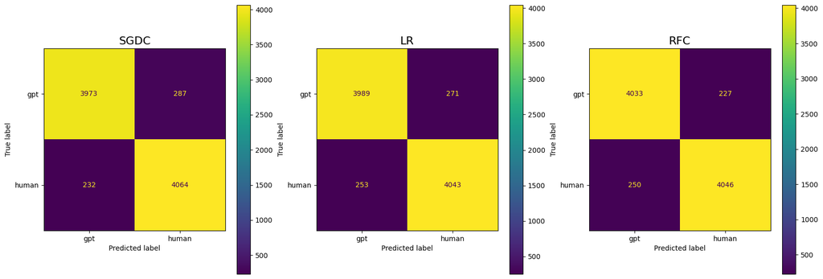

```python
fig, axes = plt.subplots(1, 3, figsize = (20, 7))

axes[0].set_title("SGDC", size = 16) # set graph title
plot_con_matrix(y_test, sgdc_predict).plot(ax = axes[0]) # plot confusion matrix

axes[1].set_title("LR", size = 16)
plot_con_matrix(y_test, lr_predict).plot(ax = axes[1])

axes[2].set_title("RFC", size = 16)
plot_con_matrix(y_test, rfc_predict).plot(ax = axes[2])
```

A brief look at each model's confusion matrix shows that all 3 models perform relatively similarly.

We will also plot each model's ROC curve.

```
<sklearn.metrics._plot.roc_curve.RocCurveDisplay at 0x23162233bd0>
```

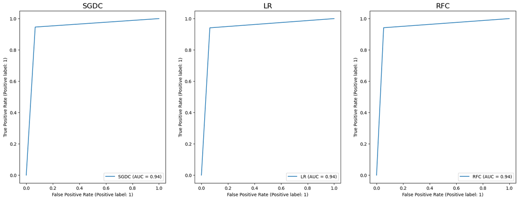

```python
fig, axes = plt.subplots(1, 3, figsize = (20, 7))
axes[0].set_title("SGDC", size = 16) # set graph title
RocCurveDisplay.from_predictions(y_test, sgdc_predict, name='SGDC', ax = axes[0]) # plot ROC curve

axes[1].set_title("LR", size = 16)
RocCurveDisplay.from_predictions(y_test, lr_predict, name = 'LR', ax = axes[1])

axes[2].set_title("RFC", size = 16)
RocCurveDisplay.from_predictions(y_test, rfc_predict, name = 'RFC', ax = axes[2])
```

Once again, this shows that all 3 models do perform quite similarly, with high AUCROC scores. Of note, all 3 models seem to have a 'point of diminishing returns' around 0.935 TPR, where the TPR does not increase significantly against the increase in FPR.

Next, we will calculate each model's:

1. Accuracy
2. AUROC Score
3. Equal Error Rate (EER)
4. Precision
5. Recall
6. FPR
7. TPR

```python
# calculate acc, roc, eer, precision, recall
sgdc_acc, sgdc_roc, sgdc_eer, sgdc_precision, sgdc_recall = calc_performance_stats(y_test, sgdc_predict, sgdc_proba)
lr_acc, lr_roc, lr_eer, lr_precision, lr_recall = calc_performance_stats(y_test, lr_predict, lr_proba)
rfc_acc, rfc_roc, rfc_eer, rfc_precision, rfc_recall = calc_performance_stats(y_test, rfc_predict, rfc_proba)

# print out stats
print(f'SGDC - Accuracy: {sgdc_acc}, ROC: {sgdc_roc}, EER: {sgdc_eer}, Precision: {sgdc_precision}, Recall: {sgdc_recall}')
print(f'LR -  Accuracy: {lr_acc}, ROC: {lr_roc}, EER: {lr_eer}, Precision: {lr_precision}, Recall: {lr_recall}')
print(f'RFC -  Accuracy: {rfc_acc}, ROC: {rfc_roc}, EER: {rfc_eer}, Precision: {rfc_precision}, Recall: {rfc_recall}')
```

```
SGDC - Accuracy: 0.9393408134642356, ROC: 0.9393126917932175, EER: 0.06126760563380282, Precision: 0.9340381521489313, Recall: 0.9459962756052142
LR -  Accuracy: 0.9387564282374942, ROC: 0.9387464919873055, EER: 0.06126760563380282, Precision: 0.9371812702828002, Recall: 0.9411080074487895
RFC -  Accuracy: 0.9442496493688639, ROC: 0.944259973247305, EER: 0.054929577464788736, Precision: 0.9468757313362977, Recall: 0.9418063314711359
```

We will also visualise the performance of the model using some bar charts.

First, we will construct lists of the calculated stats, as well as some labels and colours

```python
# assemble list of stats
accuracies =  [sgdc_acc, lr_acc, rfc_acc]
rocs = [sgdc_roc, lr_roc, rfc_roc]
eers = [sgdc_eer, lr_eer, rfc_eer]
precisions = [sgdc_precision, lr_precision, rfc_precision]
recalls = [sgdc_recall, lr_recall, rfc_recall]

# also assemble list of labels and colours
labels = ['SGDC', 'LR', 'RFC']
colors = ['tab:red', 'tab:blue', 'tab:orange']
```

Finally, we will plot the bar charts

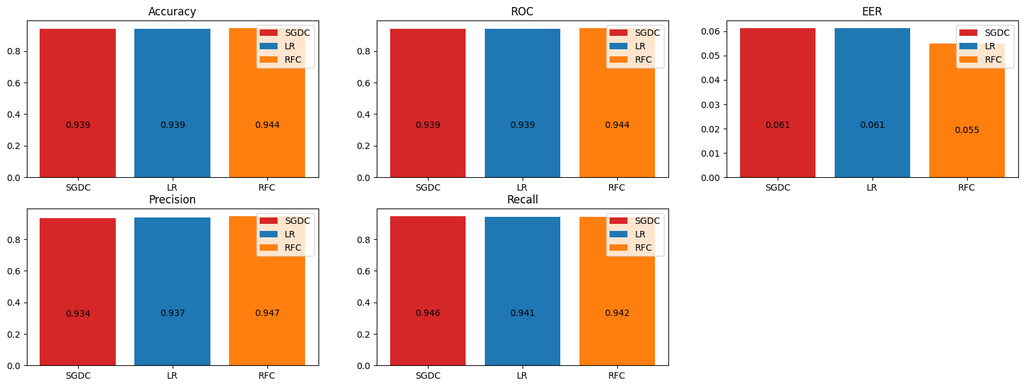

```python
fig, axes = plt.subplots(2, 3, figsize = (20, 7))

axes[0][0].set_title('Accuracy') # set plot title
axes[0][0].bar(labels, accuracies, label = labels, color = colors) # plot barplot
axes[0][0].legend() # add legend
add_val_labels(labels, accuracies, axes[0][0]) # add value labels

axes[0][1].set_title('ROC')
axes[0][1].bar(labels, rocs, label = labels, color = colors)
axes[0][1].legend()
add_val_labels(labels, rocs, axes[0][1])

axes[0][2].set_title('EER')
axes[0][2].bar(labels, eers, label = labels, color = colors)
axes[0][2].legend()
add_val_labels(labels, eers, axes[0][2])

axes[1][0].set_title('Precision')
axes[1][0].bar(labels, precisions, label = labels, color = colors)
axes[1][0].legend()
add_val_labels(labels, precisions, axes[1][0])

axes[1][1].set_title('Recall')
axes[1][1].bar(labels, recalls, label = labels, color = colors)
axes[1][1].legend()
add_val_labels(labels, recalls, axes[1][1])

fig.delaxes(axes[1][2]) # delete last empty plot
```

As can be observed from the bar charts, all 3 models perform similarly in terms of accuracy and ROC score. However, the RFC model performs significantly better in terms of EER (lower is better), and is slightly more precise than the other models.

We will also compare the FPR and TPR of the models.

```python
sgdc_fpr, sgdc_tpr = calc_fpr_tpr(y_test, sgdc_predict)
lr_fpr, lr_tpr = calc_fpr_tpr(y_test, lr_predict)
rfc_fpr, rfc_tpr = calc_fpr_tpr(y_test, rfc_predict)

print(f'SGDC - FPR: {sgdc_fpr}, TPR: {sgdc_tpr}')
print(f'LR - FPR: {lr_fpr}, TPR: {lr_tpr}')
print(f'RFC - FPR: {rfc_fpr}, TPR: {rfc_tpr}')
```

```
SGDC - FPR: 0.06737089201877934, TPR: 0.9459962756052142
LR - FPR: 0.0636150234741784, TPR: 0.9411080074487895
RFC - FPR: 0.053286384976525825, TPR: 0.9418063314711359
```

```python
fprs = [sgdc_fpr, lr_fpr, rfc_fpr]
tprs = [sgdc_tpr, lr_tpr, rfc_tpr]
```

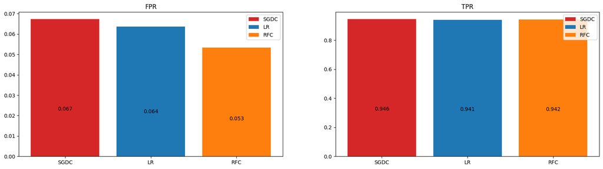

```python
fig, axes = plt.subplots(1, 2, figsize = (20, 5))

axes[0].set_title('FPR') # set plot title
axes[0].bar(labels, fprs, label = labels, color = colors) # plot barplot
axes[0].legend() # add legend
add_val_labels(labels, fprs, axes[0]) # add value labels

axes[1].set_title('TPR')
axes[1].bar(labels, tprs, label = labels, color = colors)
axes[1].legend()
add_val_labels(labels, tprs, axes[1])
```

As can be observed, the RFC has comparable TPR to the other models, but significantly lower FPR.

Since the RFC has significantly better EER and lower FPR, we would concluide that, contrary to published literature, the RFC model is the best performing model.

##### 4.2 Featureset Evaluation

Now, we will evaluate the 5 featuresets using their trained LR models. Additionally, to compare each featureset's performance with the combined performance of all 5 featuresets, we will also be comparing the LR model from the previous model evaluation, which was trained on the entire combination of all 5 featuresets (called 'Combination')

Similarly, we will begin by obtaining a brief visual overview of each featureset's performance by the confusion matrix and ROC curve for each featureset.

```
<sklearn.metrics._plot.confusion_matrix.ConfusionMatrixDisplay at 0x231628d1b50>
```

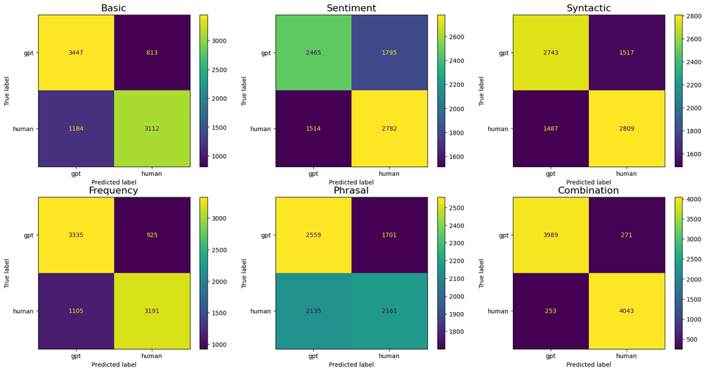

```python
fig, axes = plt.subplots(2, 3, figsize = (20, 10))

axes[0][0].set_title("Basic", size = 16) # set graph title
plot_con_matrix(y_basic_test, basic_predict).plot(ax = axes[0][0]) # plot confusion matrix

axes[0][1].set_title("Sentiment", size = 16)
plot_con_matrix(y_sentiment_test, sentiment_predict).plot(ax = axes[0][1])

axes[0][2].set_title("Syntactic", size = 16)
plot_con_matrix(y_syntactic_test, syntactic_predict).plot(ax = axes[0][2])

axes[1][0].set_title("Frequency", size = 16)
plot_con_matrix(y_frequency_test, frequency_predict).plot(ax = axes[1][0])

axes[1][1].set_title("Phrasal", size = 16)
plot_con_matrix(y_phrasal_test, phrasal_predict).plot(ax = axes[1][1])

axes[1][2].set_title("Combination", size = 16)
plot_con_matrix(y_test, lr_predict).plot(ax = axes[1][2])
```

The most obvious obervation from the confusion matrices are that the Basic and Frequency featuresets seem to yield significantly better performance than the other features, though they still perform considerably worse than Combination.

```
<sklearn.metrics._plot.roc_curve.RocCurveDisplay at 0x23162bd9550>
```

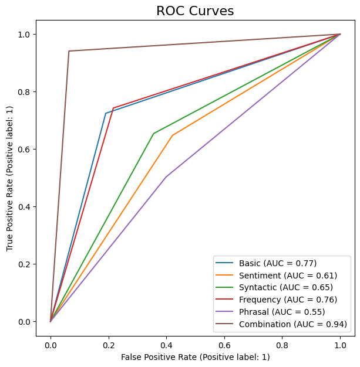

```python
fig, ax = plt.subplots(1,1, figsize = (7, 7))

ax.set_title("ROC Curves", size = 16) # set graph title

# plot curves
RocCurveDisplay.from_predictions(y_basic_test, basic_predict, name ='Basic', ax = ax)
RocCurveDisplay.from_predictions(y_sentiment_test, sentiment_predict, name ='Sentiment', ax = ax)
RocCurveDisplay.from_predictions(y_syntactic_test, syntactic_predict, name ='Syntactic', ax = ax)
RocCurveDisplay.from_predictions(y_frequency_test, frequency_predict, name ='Frequency', ax = ax)
RocCurveDisplay.from_predictions(y_phrasal_test, phrasal_predict, name ='Phrasal', ax = ax)
RocCurveDisplay.from_predictions(y_test, lr_predict, name ='Combination', ax = ax)
```

Once again, this mirrors the results of the confusion matrices, with the Basic and Frequency featuresets significantly outperforming the rest, though falling short of Combination.

Next, we will again compare their performance statistics using bar charts.

```python
# calculate acc, roc, err, precision, recall
basic_acc, basic_roc, basic_eer, basic_precision, basic_recall = calc_performance_stats(y_basic_test, basic_predict, basic_proba)
sentiment_acc, sentiment_roc, sentiment_eer, sentiment_precision, sentiment_recall = calc_performance_stats(y_sentiment_test, sentiment_predict, sentiment_proba)
syntactic_acc, syntactic_roc, syntactic_eer, syntactic_precision, syntactic_recall = calc_performance_stats(y_syntactic_test, syntactic_predict, syntactic_proba)
frequency_acc, frequency_roc, frequency_eer, frequency_precision, frequency_recall = calc_performance_stats(y_frequency_test, frequency_predict, frequency_proba)
phrasal_acc, phrasal_roc, phrasal_eer, phrasal_precision, phrasal_recall = calc_performance_stats(y_phrasal_test, phrasal_predict, phrasal_proba)

# print stats
print(f'Basic - Accuracy: {basic_acc}, ROC: {basic_roc}, EER: {basic_eer}, Precision: {basic_precision}, Recall: {basic_recall}')
print(f'Sentiment - Accuracy: {sentiment_acc}, ROC: {sentiment_roc}, EER: {sentiment_eer}, Precision: {sentiment_precision}, Recall: {sentiment_recall}')
print(f'Syntactic - Accuracy: {syntactic_acc}, ROC: {syntactic_roc}, EER: {syntactic_eer}, Precision: {syntactic_precision}, Recall: {syntactic_recall}')
print(f'Frequency - Accuracy: {frequency_acc}, ROC: {frequency_roc}, EER: {frequency_eer}, Precision: {frequency_precision}, Recall: {frequency_recall}')
print(f'Phrasal - Accuracy: {phrasal_acc}, ROC: {phrasal_roc}, EER: {phrasal_eer}, Precision: {phrasal_precision}, Recall: {phrasal_recall}')
print(f'Combination -  Accuracy: {lr_acc}, ROC: {lr_roc}, EER: {lr_eer}, Precision: {lr_precision}, Recall: {lr_recall}')
```

```
Basic - Accuracy: 0.7665965404394577, ROC: 0.7667748577123823, EER: 0.23309859154929577, Precision: 0.7928662420382165, Recall: 0.7243947858472998
Sentiment - Accuracy: 0.6132538569424965, ROC: 0.6131088205208908, EER: 0.39154929577464787, Precision: 0.6078217172820625, Recall: 0.6475791433891993
Syntactic - Accuracy: 0.648901355773726, ROC: 0.6488803866026701, EER: 0.35140845070422533, Precision: 0.6493296347665279, Recall: 0.6538640595903166
Frequency - Accuracy: 0.762739597942964, ROC: 0.7628239174338395, EER: 0.23215962441314553, Precision: 0.7752672497570456, Recall: 0.7427839851024208
Phrasal - Accuracy: 0.5516596540439458, ROC: 0.5518651480578068, EER: 0.44084507042253523, Precision: 0.5595546349041948, Recall: 0.5030260707635009
Combination -  Accuracy: 0.9387564282374942, ROC: 0.9387464919873055, EER: 0.06126760563380282, Precision: 0.9371812702828002, Recall: 0.9411080074487895
```

```python
# assemble list of stats
featuresets_accuracies =  [basic_acc, sentiment_acc, syntactic_acc, frequency_acc, phrasal_acc, lr_acc]
featuresets_rocs = [basic_roc, sentiment_roc, syntactic_roc, frequency_roc, phrasal_roc, lr_roc]
featuresets_eers = [basic_eer, sentiment_eer, syntactic_eer, frequency_eer, phrasal_eer, lr_eer]
featuresets_precisions = [basic_precision, sentiment_precision, syntactic_precision, frequency_precision, phrasal_precision, lr_precision]
featuresets_recalls = [basic_recall, sentiment_recall, syntactic_recall, frequency_recall, phrasal_recall, lr_recall]

# also assemble list of labels and colours
featuresets_labels = ['Basic', 'Sentiment', 'Syntactic', 'Frequency', 'Phrasal', 'Combination']
featuresets_colors = ['tab:blue', 'tab:orange', 'tab:green', 'tab:red', 'tab:purple', 'tab:brown']
```

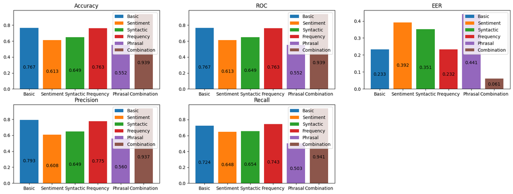

```python
fig, axes = plt.subplots(2, 3, figsize = (20, 7))

axes[0][0].set_title('Accuracy') # add title
axes[0][0].bar(featuresets_labels, featuresets_accuracies, label = featuresets_labels, color = featuresets_colors) # plot bar plot
axes[0][0].legend() # add legend
add_val_labels(featuresets_labels, featuresets_accuracies, axes[0][0]) # ad value label

axes[0][1].set_title('ROC')
axes[0][1].bar(featuresets_labels, featuresets_rocs, label = featuresets_labels, color = featuresets_colors)
axes[0][1].legend()
add_val_labels(featuresets_labels, featuresets_rocs, axes[0][1])

axes[0][2].set_title('EER')
axes[0][2].bar(featuresets_labels, featuresets_eers, label = featuresets_labels, color = featuresets_colors)
axes[0][2].legend()
add_val_labels(featuresets_labels, featuresets_eers, axes[0][2])

axes[1][0].set_title('Precision')
axes[1][0].bar(featuresets_labels, featuresets_precisions, label = featuresets_labels, color = featuresets_colors)
axes[1][0].legend()
add_val_labels(featuresets_labels, featuresets_precisions, axes[1][0])

axes[1][1].set_title('Recall')
axes[1][1].bar(featuresets_labels, featuresets_recalls, label = featuresets_labels, color = featuresets_colors)
axes[1][1].legend()
add_val_labels(featuresets_labels, featuresets_recalls, axes[1][1])

fig.delaxes(axes[1][2]) # delete empty plot
```

```python
basic_fpr, basic_tpr = calc_fpr_tpr(y_basic_test, basic_predict)
sentiment_fpr, sentiment_tpr = calc_fpr_tpr(y_sentiment_test, sentiment_predict)
syntactic_fpr, syntactic_tpr = calc_fpr_tpr(y_syntactic_test, syntactic_predict)
frequency_fpr, frequency_tpr = calc_fpr_tpr(y_frequency_test, frequency_predict)
phrasal_fpr, phrasal_tpr = calc_fpr_tpr(y_phrasal_test, phrasal_predict)

print(f'Basic- FPR: {basic_fpr}, TPR: {basic_tpr}')
print(f'Sentiment - FPR: {sentiment_fpr}, TPR: {sentiment_tpr}')
print(f'Syntactic - FPR: {syntactic_fpr}, TPR: {syntactic_tpr}')
print(f'Frequency - FPR: {frequency_fpr}, TPR: {frequency_tpr}')
print(f'Phrasal - FPR: {phrasal_fpr}, TPR: {phrasal_tpr}')
print(f'Combination - FPR: {lr_fpr}, TPR: {lr_tpr}')
```

```
Basic- FPR: 0.1908450704225352, TPR: 0.7243947858472998
Sentiment - FPR: 0.4213615023474178, TPR: 0.6475791433891993
Syntactic - FPR: 0.3561032863849765, TPR: 0.6538640595903166
Frequency - FPR: 0.21713615023474178, TPR: 0.7427839851024208
Phrasal - FPR: 0.39929577464788735, TPR: 0.5030260707635009
Combination - FPR: 0.0636150234741784, TPR: 0.9411080074487895
```

```python
fprs = [basic_fpr, sentiment_fpr, syntactic_fpr, frequency_fpr, phrasal_fpr, lr_fpr]
tprs = [basic_tpr, sentiment_tpr, syntactic_tpr, frequency_tpr, phrasal_tpr, lr_tpr]
```

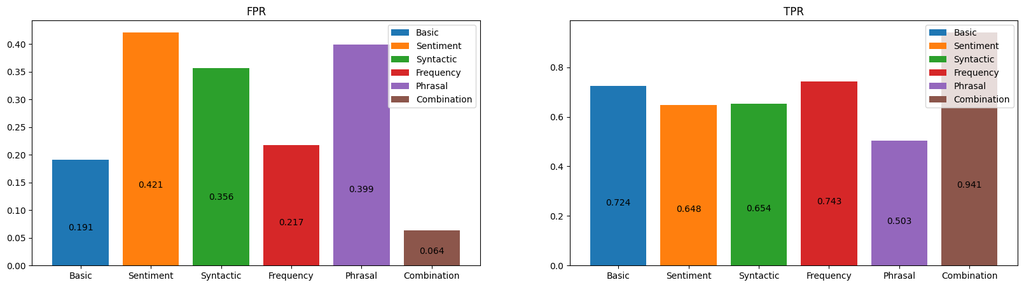

```python
fig, axes = plt.subplots(1, 2, figsize = (20, 5))

axes[0].set_title('FPR') # set plot title
axes[0].bar(featuresets_labels, fprs, label = featuresets_labels, color = featuresets_colors) # plot barplot
axes[0].legend() # add legend
add_val_labels(featuresets_labels, fprs, axes[0]) # add value labels

axes[1].set_title('TPR')
axes[1].bar(featuresets_labels, tprs, label = featuresets_labels, color = featuresets_colors)
axes[1].legend()
add_val_labels(featuresets_labels, tprs, axes[1])
```

Once again, Basic and Frequency outperform the other featuresets by a large margin, though still falling far below Combination.

Of particular concern is the extremely high EER for each featureset compared to Combination. The nearest competitor to Combination (Frequency), is still nearly 4 times the EER of the Cbom. This is a strong indication that the combined model significantly outperforms individual featuresets, possibly beyond the previously observed amounts.

#### 5. Additional RFC and BAF Featureset Combination Test

Now that we have identified the best performing model (RFC), and the best performing featuresets (Combination, or when isolated - Basic and Frequency), we would like to perform an additional test.

In this test, we would like to explore combining the two top performing isolated datasets (Basic and Frequency), and if such an RFC including only the Basic and Frequency datasets (called RFC(BAF)) would yield comparable/better performance than a combination RFC model (called RFC(Combination))

```python
#select is_human as target
y = df['is_human'] # target

basic_and_freq = x[['word_count', 'sentence_count', 'char_count', 'avg_sentence_len', 'avg_word_len', 'zipfian_difference', 'unique_word_proportion', 'stopword_proportion']]
combi_rfc = df.loc[:, ~df.columns.isin(['question', 'answer', 'is_human', 'filtered_answer', 'lemmatised_answer'])]
basic_and_freq
```

|  | word_count | sentence_count | char_count | avg_sentence_len | avg_word_len | zipfian_difference | unique_word_proportion | stopword_proportion |
| --- | --- | --- | --- | --- | --- | --- | --- | --- |
| 0 | 228 | 7 | 1258 | 32.571429 | 5.517544 | 0.295445 | 0.460526 | 0.482456 |
| 1 | 154 | 5 | 851 | 30.800000 | 5.525974 | 0.364823 | 0.493506 | 0.383117 |
| 2 | 146 | 4 | 698 | 36.500000 | 4.780822 | 0.376035 | 0.527397 | 0.486301 |
| 3 | 178 | 5 | 944 | 35.600000 | 5.303371 | 0.310059 | 0.466292 | 0.443820 |
| 4 | 179 | 3 | 973 | 59.666667 | 5.435754 | 0.359993 | 0.508380 | 0.424581 |
| ... | ... | ... | ... | ... | ... | ... | ... | ... |
| 42775 | 132 | 5 | 646 | 26.400000 | 4.893939 | 0.472320 | 0.598485 | 0.477273 |
| 42776 | 132 | 7 | 590 | 18.857143 | 4.469697 | 0.575167 | 0.659091 | 0.371212 |
| 42777 | 357 | 17 | 1827 | 21.000000 | 5.117647 | 0.392522 | 0.504202 | 0.333333 |
| 42778 | 214 | 8 | 1178 | 26.750000 | 5.504673 | 0.424332 | 0.556075 | 0.392523 |
| 42779 | 177 | 6 | 950 | 29.500000 | 5.367232 | 0.450822 | 0.598870 | 0.361582 |

42780 rows × 8 columns

Scale the x values

```python
basic_and_freq_scaled = scale_values(basic_and_freq)
combi_rfc_scaled = scale_values(combi_rfc)
```

Split data set in to training and testing sets

```python
x_baf_train, x_baf_test, y_baf_train, y_baf_test = train_test_split(basic_and_freq_scaled, y, test_size = 0.2, random_state = 42)
x_combi_train, x_combi_test, y_combi_train, y_combi_test = train_test_split(combi_rfc_scaled, y, test_size = 0.2, random_state = 42)
```

Initialise RFCs

```python
rfc_combination = RandomForestClassifier()
rfc_baf = RandomForestClassifier()
```

Train RFCs on training data

```python
rfc_combination.fit(x_combi_train, y_combi_train)
rfc_baf.fit(x_baf_train, y_baf_train)
```

```
RandomForestClassifier()
```

Generate predictions and class probabilities

```python
rfc_combi_predict = rfc_combination.predict(x_combi_test)
rfc_baf_predict = rfc_baf.predict(x_baf_test)
```

```python
rfc_baf_proba = rfc_baf.predict_proba(x_baf_test)
rfc_baf_proba = rfc_baf_proba[:, 1] # keep only the probability of the positive class

rfc_combi_proba = rfc_combination.predict_proba(x_combi_test)
rfc_combi_proba = rfc_combi_proba[:, 1] # keep only the probability of the positive class
```

We will start by plotting the confusion matrices and ROC curves

```
<sklearn.metrics._plot.confusion_matrix.ConfusionMatrixDisplay at 0x2316b18cc50>
```

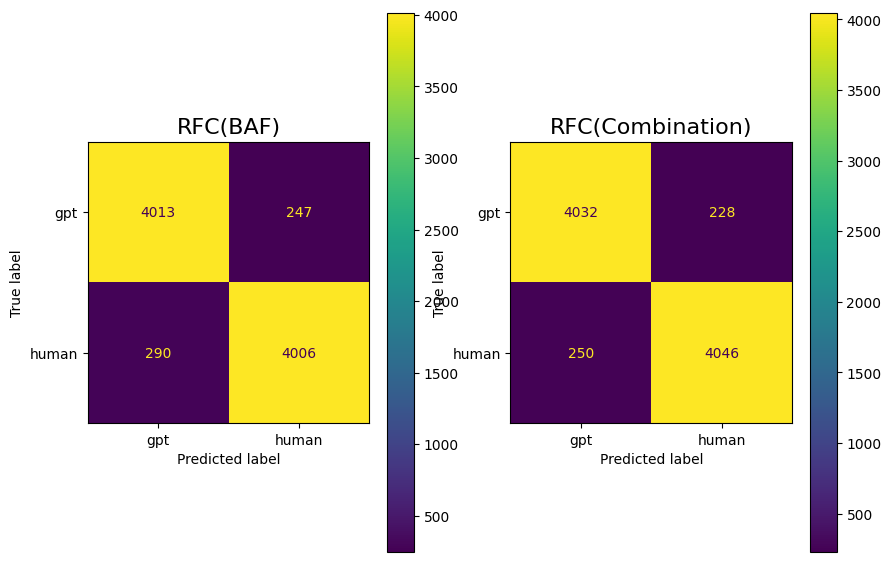

```python
fig, ax = plt.subplots(1, 2, figsize = (10, 7))

ax[0].set_title("RFC(BAF)", size = 16) # set graph title
plot_con_matrix(y_baf_test, rfc_baf_predict).plot(ax = ax[0]) # plot confusion matrix

ax[1].set_title("RFC(Combination)", size = 16)
plot_con_matrix(y_combi_test, rfc_combi_predict).plot(ax = ax[1])
```

A cursory examination of both confusion matrices indicates that they have relatively similar performance.

```
<sklearn.metrics._plot.roc_curve.RocCurveDisplay at 0x23163c6a450>
```

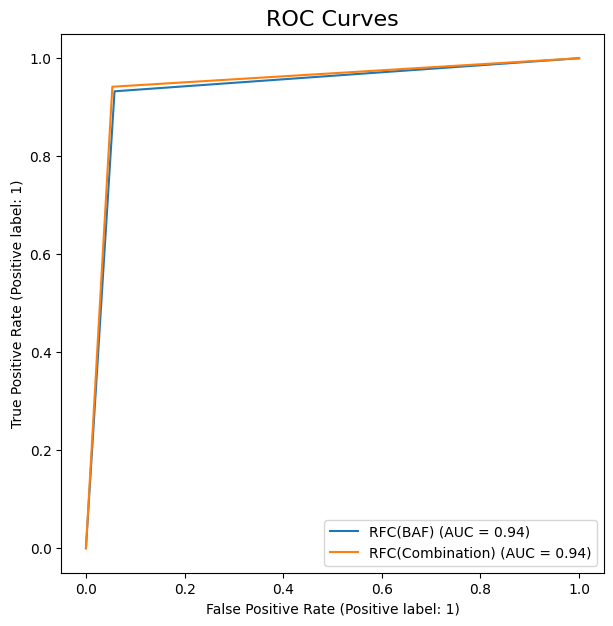

```python
fig, ax = plt.subplots(1,1, figsize = (7, 7))

ax.set_title("ROC Curves", size = 16) # set graph title

# plot curves
RocCurveDisplay.from_predictions(y_baf_test, rfc_baf_predict, name ='RFC(BAF)', ax = ax)
RocCurveDisplay.from_predictions(y_combi_test, rfc_combi_predict, name ='RFC(Combination)', ax = ax)
```

The ROC curves also reveal that both have very similar performance, though RFC(Combination) performs very slightly better.\

Next, we will compare the RFCs' performance statistics using bar charts

```python
# calculate performance stats
baf_acc, baf_roc, baf_eer, baf_precision, baf_recall = calc_performance_stats(y_baf_test, rfc_baf_predict, rfc_baf_proba)
combi_acc, combi_roc, combi_eer, combi_precision, combi_recall = calc_performance_stats(y_combi_test, rfc_combi_predict, rfc_combi_proba)


# print out stats
print(f'RFC(BAF) -  Accuracy: {baf_acc}, ROC: {baf_roc}, EER: {baf_eer}, Precision: {baf_precision}, Recall: {baf_recall}')
print(f'RFC(Combination) -  Accuracy: {combi_acc}, ROC: {combi_roc}, EER: {combi_eer}, Precision: {combi_precision}, Recall: {combi_recall}')
```

```
RFC(BAF) -  Accuracy: 0.9372370266479664, ROC: 0.9372570619246204, EER: 0.06103286384976526, Precision: 0.9419233482247825, Recall: 0.9324953445065177
RFC(Combination) -  Accuracy: 0.9441327723235157, ROC: 0.9441426023552864, EER: 0.054460093896713614, Precision: 0.9466541881141788, Recall: 0.9418063314711359
```

```python
# assemble combined list of stats
baf_combi_accuracies =  [baf_acc, combi_acc]
baf_combi_rocs = [baf_roc, combi_roc]
baf_combi_eers = [baf_eer, combi_eer]
baf_combi_precisions = [baf_precision, combi_precision]
baf_combi_recalls = [baf_recall, combi_recall]

# also assemble list of labels and colours
baf_combi_labels = ['RFC(BAF)', 'RFC(Combination)']
baf_combi_colors = ['tab:blue', 'tab:orange']
```

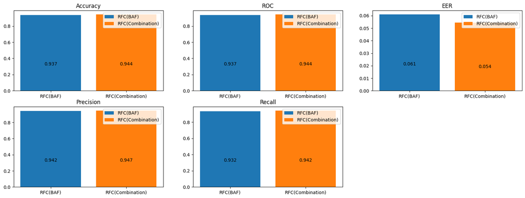

```python
fig, axes = plt.subplots(2, 3, figsize = (20, 7))

axes[0][0].set_title('Accuracy') # add title
axes[0][0].bar(baf_combi_labels, baf_combi_accuracies, label = baf_combi_labels, color = baf_combi_colors) # plot bar plot
axes[0][0].legend() # add legend
add_val_labels(baf_combi_labels, baf_combi_accuracies, axes[0][0]) # ad value label

axes[0][1].set_title('ROC')
axes[0][1].bar(baf_combi_labels, baf_combi_rocs, label = baf_combi_labels, color = baf_combi_colors)
axes[0][1].legend()
add_val_labels(baf_combi_labels, baf_combi_rocs, axes[0][1])

axes[0][2].set_title('EER')
axes[0][2].bar(baf_combi_labels, baf_combi_eers, label = baf_combi_labels, color = baf_combi_colors)
axes[0][2].legend()
add_val_labels(baf_combi_labels, baf_combi_eers, axes[0][2])

axes[1][0].set_title('Precision')
axes[1][0].bar(baf_combi_labels, baf_combi_precisions, label = baf_combi_labels, color = baf_combi_colors)
axes[1][0].legend()
add_val_labels(baf_combi_labels, baf_combi_precisions, axes[1][0])

axes[1][1].set_title('Recall')
axes[1][1].bar(baf_combi_labels, baf_combi_recalls, label = baf_combi_labels, color = baf_combi_colors)
axes[1][1].legend()
add_val_labels(baf_combi_labels, baf_combi_recalls, axes[1][1])

fig.delaxes(axes[1][2]) # delete last empty plot
```

We will also compare their FPRs and TPRs

```python
baf_fpr, baf_tpr = calc_fpr_tpr(y_baf_test, rfc_baf_predict)
combi_fpr, combi_tpr = calc_fpr_tpr(y_combi_test, rfc_combi_predict)

print(f'BAF FPR: {baf_fpr}, TPR: {baf_tpr}')
print(f'Combination - FPR: {combi_fpr}, TPR: {combi_tpr}')
```

```
BAF FPR: 0.057981220657277, TPR: 0.9324953445065177
Combination - FPR: 0.05352112676056338, TPR: 0.9418063314711359
```

```python
fprs = [baf_fpr, combi_fpr]
tprs = [baf_tpr, combi_tpr]
```

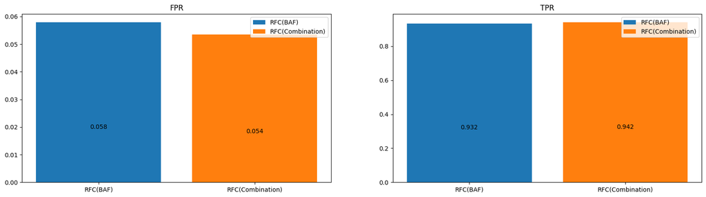

```python
fig, axes = plt.subplots(1, 2, figsize = (20, 5))

axes[0].set_title('FPR') # set plot title
axes[0].bar(baf_combi_labels, fprs, label = baf_combi_labels, color = baf_combi_colors) # plot barplot
axes[0].legend() # add legend
add_val_labels(baf_combi_labels, fprs, axes[0]) # add value labels

axes[1].set_title('TPR')
axes[1].bar(baf_combi_labels, tprs, label = baf_combi_labels, color = baf_combi_colors)
axes[1].legend()
add_val_labels(baf_combi_labels, tprs, axes[1])
```

From the performance statistics, we can observe that the performance of both RFC models is extremely similar, with the exception of EER, where RFC(Combination) still performs significantly better.

This raises the interesting possibility that RFC(BAF) might be a better approach in certain circumstances. In situations where access to computing power or space is limited, RFC(BAF) might be a better option, as it requires a smaller number of features. Additionally, the features used in the Basic and Frequency datasets are computationally faster, and require significantly less technical expertise to extract.

#### 6. Conclusions

From the testing and evaluation carried out above, we have identified the 2 main points of focus for our final prototype:

1. A RFC Classifier will be used.
2. The entire combination of all 5 features will be used. (Though RFC(BAF) is promising, RFC(Combination) still yields better overall performance)

#### 6. References

[1] Lavanya Reddy. 2019. Answer to “AttributeError: probability estimates are not available for loss=’hinge’.” Stack Overflow. Retrieved June 28, 2023 from https://stackoverflow.com/a/57789235

[2] Craig. 2017. Answer to “Best Fit Line on Log Log Scales in python 2.7.” Stack Overflow. Retrieved August 18, 2023 from https://stackoverflow.com/a/43838500

[3] James S. 2017. Answer to “Equal Error Rate in Python.” Stack Overflow. Retrieved June 7, 2023 from https://stackoverflow.com/a/46026962